# RQ1 Step 3: Fitting, tuning and comparing models

## 2.2 Features (the predictors)

```r
Y <- "rel_log_cost_m2"

# numeric drivers (Step 1 built them; Step 2 kept them)
num_main <- c("rel_house_m2",        # house size relative to other districts (log ratio)
              "log_houses_n",        # how many new houses (log)
              "multiunit_share",     # share of new dwellings that are not stand-alone houses
              "apt_share",           # share that are apartments
              "retire_share",        # share that are retirement-village units
              "dwell_per_1000",      # new dwellings per 1000 residents (12 months)
              "houses_yoy",          # growth in house numbers vs the same quarter last year (log)
              "log_resid_alt_real",  # real $ of residential alterations (log)
              "log_nonres_real")     # real $ of new non-residential building (log)

# two feature sets
fsets <- list(
  drivers  = c(num_main, "region", "is_city"),  # measurable drivers + broad location
  district = c(num_main, "ta")                  # measurable drivers + the district itself
)

tibble(feature = c(num_main, "region", "is_city", "ta"),
       type    = map_chr(feature, \(v) class(train[[v]])[1]),
       `in drivers set`  = feature %in% fsets$drivers,
       `in district set` = feature %in% fsets$district) |>
  kable(caption = "Features in each set")
```

Features in each set

| feature | type | in drivers set | in district set |
| --- | --- | --- | --- |
| rel_house_m2 | numeric | TRUE | TRUE |
| log_houses_n | numeric | TRUE | TRUE |
| multiunit_share | numeric | TRUE | TRUE |
| apt_share | numeric | TRUE | TRUE |
| retire_share | numeric | TRUE | TRUE |
| dwell_per_1000 | numeric | TRUE | TRUE |
| houses_yoy | numeric | TRUE | TRUE |
| log_resid_alt_real | numeric | TRUE | TRUE |
| log_nonres_real | numeric | TRUE | TRUE |
| region | factor | TRUE | FALSE |
| is_city | logical | TRUE | FALSE |
| ta | factor | FALSE | TRUE |

**Why two feature sets?** RQ1 asks *what drives* cost. The district name is not a driver: it is a label that soaks up everything about a place that our measured features miss (land, terrain, local builders, consent rules).

- The **drivers** set leaves the district name out. Whatever it explains has to come from measurable things.
- The **district** set adds the name. The gap between the two sets shows how much of the location effect our features *don’t* explain.

`region` and `is_city` are left out of the district set because the district already determines them. In a linear model they would be perfectly collinear and their coefficients could not be estimated.

**Left out on purpose**

- anything built from house *value* (leakage, Step 1);
- lagged cost (a forecasting question, not an explanatory one; Step 2 decision 8);
- island and season (no signal, Step 2 decision 3);
- the time index (the relative response has no trend to follow);
- `avg_house_m2`, which is replaced by `rel_house_m2` for the relative response (Step 2 decision 5).

## 2.3 Rows

```r
rq1 |> filter(year >= 1996) |>
  filter(ta %in% c("Chatham Islands Territory", "Kawerau District")) |>
  count(ta, split) |> kable(caption = "Rows dropped (1996 onwards)")
```

Rows dropped (1996 onwards)

| ta | split | n |
| --- | --- | --- |
| Chatham Islands Territory | test | 1 |
| Chatham Islands Territory | train | 1 |
| Kawerau District | test | 2 |
| Kawerau District | train | 1 |

```r
colSums(is.na(train[c(num_main, "rel_log_cost_m2")]))   # expect all zero
```

```
##       rel_house_m2       log_houses_n    multiunit_share          apt_share
##                  0                  0                  0                  0
##       retire_share     dwell_per_1000         houses_yoy log_resid_alt_real
##                  0                  0                  0                  0
##    log_nonres_real    rel_log_cost_m2
##                  0                  0
```

**Observation.** From 1996 every feature is present, so nothing needs imputing. We drop **Chatham Islands** and **Kawerau**, which have only 1–2 modelled rows each. A district effect can’t be learned from one row, and their names would appear in the test data but in no training fold (R stops with *“factor has new levels”*).

# 3 Compute check: will this fit on a laptop?

```r
design_district <- make_x(train, paste(fsets$district, collapse = " + "))
tibble(object = c("all modelled rows (rq1)", "training rows", "design matrix, district set"),
       rows   = c(nrow(rq1), nrow(train), nrow(design_district)),
       columns = c(ncol(rq1), ncol(train), ncol(design_district)),
       MB     = c(object.size(rq1), object.size(train), object.size(design_district)) / 2^20) |>
  kable(digits = 2)
```

| object | rows | columns | MB |
| --- | --- | --- | --- |
| all modelled rows (rq1) | 8662 | 43 | 2.57 |
| training rows | 5694 | 43 | 1.69 |
| design matrix, district set | 5694 | 73 | 3.53 |

```r
ram_gb <- tryCatch(as.numeric(system("sysctl -n hw.memsize", intern = TRUE)) / 2^30,   # macOS only
                   error = function(e) NA, warning = function(e) NA)
c(cores_available = parallel::detectCores(), cores_used = N_CORES, RAM_GB = ram_gb)
```

```
## cores_available      cores_used          RAM_GB
##               8               7               8
```

**Observation.** The data takes a few megabytes. The machine has gigabytes. Memory is not a constraint. The heaviest object will be a 500-tree random forest (tens of MB). The real cost is *time*: every tuning setting is fitted four times (one per fold). That’s why the slow chunks are cached, and why `ranger` and `xgboost` use several cores.

# 4 How models are compared fairly

## 4.1 Metrics

All errors are on the **log scale**, where an error of 0.10 ≈ 10% of $/m².

- **RMSE** (root mean squared error): penalises big misses. It is the main score.
- **MAE** (mean absolute error): the typical miss.
- **R²**: share of the variation explained. 0 = no better than predicting the average; 1 = perfect.
- **MAPE** on $/m² (test only): the pitch’s metric. Predicted $/m² = e<sup>prediction</sup> × (the other districts’ $/m² that quarter).

## 4.2 Time-ordered cross-validation

Tuning needs a score for each candidate setting, computed on data the model did not train on. We can’t use the test set for this (ground rule 2). Ordinary random k-fold CV would mix 2018 rows into training when validating on 2014, which lets the model see the future. We use **forward-chaining** folds instead: train on every year before a block, validate on the block.

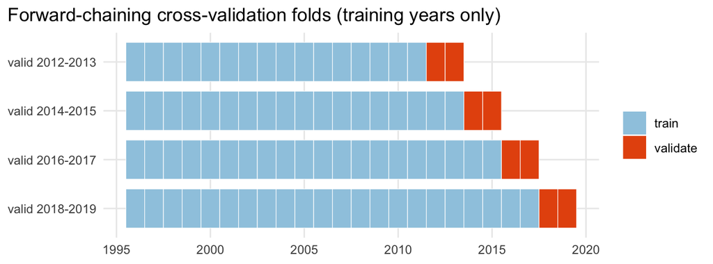

```r
folds <- make_time_folds(train$year)

fold_plot <- imap_dfr(folds, \(f, nm) bind_rows(
  tibble(fold = nm, year = unique(train$year[f$train]), role = "train"),
  tibble(fold = nm, year = unique(train$year[f$valid]), role = "validate")))

p_folds <- ggplot(fold_plot, aes(year, fct_rev(fold), fill = role)) +
  geom_tile(colour = "white", height = 0.8) +
  scale_fill_manual(values = c(train = "#9ecae1", validate = "#e6550d")) +
  labs(title = "Forward-chaining cross-validation folds (training years only)",
       x = NULL, y = NULL, fill = NULL)
save_fig(p_folds, "fig15_cv_folds", height = 2.6)
```

```r
sapply(folds, \(f) c(train_rows = length(f$train), valid_rows = length(f$valid)))
```

```
##            valid 2012-2013 valid 2014-2015 valid 2016-2017 valid 2018-2019
## train_rows            3793            4261            4724            5204
## valid_rows             468             463             480             490
```

**Observation.** There are four folds, each validating on two years (about 470 rows) after training on 3,800–5,200 rows. The last fold (train 1996–2017, validate 2018–19) is closest to the real task. The **CV score** of a setting is its average RMSE over the four folds. Its spread across folds gives a standard error.

## 4.3 How tuning works, and the one-standard-error rule

For each model, `cv_tune()` (in `R/utils_models.R`) does the following:

1. for every row of a grid of settings and every fold, fit on the fold’s training rows and predict its validation rows;
2. average the validation RMSE over folds;
3. return the setting with the lowest average.

**Choosing between models** uses the **one-standard-error rule**: take the lowest CV RMSE, add one standard error, and choose the *simplest* model under that line. Differences smaller than the fold-to-fold noise are not worth the extra complexity or the lost interpretability.

Every model below is written as a small “factory”: `fp_x(vars, y)` returns a function that fits on one data set and predicts another. `tune_model()` runs it on both feature sets.

```r
rhs_of <- function(vars) paste(vars, collapse = " + ")
fml_of <- function(y, vars) as.formula(paste(y, "~", rhs_of(vars)))
is_num <- function(v) is.numeric(train[[v]])

tune_model <- function(factory, grid = NULL, inner = NULL, sets = fsets, y = Y) {
  imap(sets, \(vars, nm) timed(cv_tune(factory(vars, y), grid, train, folds, y, inner)))
}

# fingerprint of everything the cached tuning chunks depend on (if any of it changes, they re-run)
knitr::opts_chunk$set(cache.extra = list(file_md5, rlang::hash(list(train, folds, fsets, Y, N_CORES))))
```

# 5 Baselines

**What they are.** The *overall mean* predicts the training average for every row. The *district mean* predicts each district’s own training average (the baseline Step 2 chose). Any useful model must beat the district mean; otherwise “it’s Queenstown, so it’s dear” would be all we’ve learned.

```r
fp_mean <- function(vars, y) function(tr, nw, p) rep(mean(tr[[y]]), nrow(nw))

fp_district_mean <- function(vars, y) function(tr, nw, p) {
  m   <- tapply(tr[[y]], tr$ta, mean)        # one average per district
  out <- unname(m[as.character(nw$ta)])
  ifelse(is.na(out), mean(tr[[y]]), out)     # a district never seen gets the overall mean
}

res_mean     <- tune_model(fp_mean,          sets = list(none = character(0)))
res_distmean <- tune_model(fp_district_mean, sets = list(none = character(0)))
bind_rows(summarise_tuning(res_mean, "Overall mean"),
          summarise_tuning(res_distmean, "District mean")) |>
  select(model, cv_rmse, cv_rmse_se, cv_mae, cv_r2) |> kable(digits = 4)
```

| model | cv_rmse | cv_rmse_se | cv_mae | cv_r2 |
| --- | --- | --- | --- | --- |
| Overall mean | 0.1047 | 0.0048 | 0.0801 | -0.0131 |
| District mean | 0.0841 | 0.0029 | 0.0644 | 0.3362 |

**Observation.** The overall mean misses by about 0.105 on the log scale (≈ 10%). Knowing only the district cuts this to 0.084 (CV R² = 0.34). That is a strong baseline: Step 2 showed that districts keep their rank for decades. **This is the number to beat.**

# 6 Linear regression (OLS)

**What it is.** *Ordinary least squares*. Prediction = intercept + b₁·x₁ + b₂·x₂ + …. The coefficients b are chosen to minimise the sum of squared errors. Each coefficient is the change in the response for a one-unit change in that feature, *holding the others fixed*. There is nothing to tune.

**Assumptions.** Effects are straight lines and add up. Errors have constant spread. For valid p-values, rows must also be independent. Our rows are not (the same district appears quarter after quarter), so we use OLS for *prediction and description*, not for formal significance tests.

```r
fp_ols <- function(vars, y) function(tr, nw, p) predict(lm(fml_of(y, vars), data = tr), newdata = nw)
res_ols <- tune_model(fp_ols)
summarise_tuning(res_ols, "Linear regression") |> select(set, cv_rmse, cv_rmse_se, cv_r2) |> kable(digits = 4)
```

| set | cv_rmse | cv_rmse_se | cv_r2 |
| --- | --- | --- | --- |
| drivers | 0.0899 | 0.0020 | 0.2339 |
| district | 0.0814 | 0.0024 | 0.3782 |

```r
# coefficients of the drivers model fitted on all training rows (numeric features standardised so sizes compare)
ols_std <- lm(fml_of(Y, fsets$drivers),
              data = train |> mutate(across(all_of(num_main), \(x) as.numeric(scale(x)))))
broom_like <- summary(ols_std)$coefficients
tibble(term = rownames(broom_like), estimate = broom_like[, 1], std_error = broom_like[, 2]) |>
  filter(term %in% num_main | term == "is_cityTRUE") |>
  arrange(desc(abs(estimate))) |>
  kable(digits = 4, caption = "OLS, drivers set: effect of a 1-SD change in each feature (log points)")
```

OLS, drivers set: effect of a 1-SD change in each feature (log points)

| term | estimate | std_error |
| --- | --- | --- |
| log_resid_alt_real | 0.0491 | 0.0030 |
| dwell_per_1000 | 0.0313 | 0.0018 |
| log_houses_n | -0.0234 | 0.0033 |
| is_cityTRUE | 0.0072 | 0.0044 |
| rel_house_m2 | -0.0068 | 0.0013 |
| houses_yoy | -0.0016 | 0.0013 |
| apt_share | 0.0015 | 0.0017 |
| multiunit_share | -0.0008 | 0.0021 |
| log_nonres_real | 0.0008 | 0.0019 |
| retire_share | 0.0007 | 0.0016 |

**Observation.** OLS on the drivers alone (CV RMSE 0.0899, R² 0.23) beats the overall mean, but **not** the district mean. With the district added (0.0814, R² 0.38) it beats both: the drivers explain *changes* within a district that the district average can’t. In the standardised coefficients, a positive estimate means “districts with more of this feature are dearer, other features held equal”. Alteration spending and dwellings per 1,000 residents are positive; the number of new houses and relative house size are negative. Because the activity measures overlap (VIF up to ~6 in Step 2), individual coefficients can swap size or even sign between similar models. Treat them as a description, not a causal effect.

# 7 Polynomial regression

**What it is.** Still a linear model, but each numeric feature x is also given x², x³, … as extra columns, so its effect can bend. `poly(x, d)` builds *orthogonal* polynomials, which carry the same information as x, x², … but are uncorrelated with each other, so the fit is numerically stable. **Tuned:** the degree d (1 = plain OLS).

**Risk.** High-degree polynomials swing wildly beyond the range of the training data. That matters when the test years bring feature values never seen before.

```r
fp_poly <- function(vars, y) function(tr, nw, p) {
  terms <- map_chr(vars, \(v) if (is_num(v)) sprintf("poly(%s, %d)", v, p$degree) else v)
  predict(lm(as.formula(paste(y, "~", paste(terms, collapse = " + "))), data = tr), newdata = nw)
}
res_poly <- tune_model(fp_poly, grid = tibble(degree = 1:3))
res_poly$drivers$summary |> select(degree, cv_rmse, cv_rmse_sd, cv_r2) |> kable(digits = 4, caption = "Drivers set")
```

Drivers set

| degree | cv_rmse | cv_rmse_sd | cv_r2 |
| --- | --- | --- | --- |
| 2 | 0.0890 | 0.0033 | 0.2521 |
| 3 | 0.0891 | 0.0032 | 0.2502 |
| 1 | 0.0899 | 0.0040 | 0.2339 |

```r
summarise_tuning(res_poly, "Polynomial regression") |> select(set, best_settings, cv_rmse, cv_r2) |> kable(digits = 4)
```

| set | best_settings | cv_rmse | cv_r2 |
| --- | --- | --- | --- |
| drivers | degree = 2 | 0.0890 | 0.2521 |
| district | degree = 1 | 0.0814 | 0.3782 |

**Observation.** For the drivers set, degree 2 is best, but only slightly better than straight lines (0.089 vs 0.0899). For the district set, degree 1 wins, so plain OLS. The relationships bend a little but are close to linear.

# 8 Ridge, lasso and elastic net (regularised regression)

**What they are.** OLS with a **penalty** on the size of the coefficients:

$$\min_b \; \sum (y - Xb)^2 / 2n \;+\; \lambda \left[
\tfrac{1-\alpha}{2}\sum b_j^2 + \alpha \sum |b_j| \right]$$

- **Ridge** (α = 0) shrinks all coefficients towards zero. It helps when features overlap (our VIFs).
- **Lasso** (α = 1) can shrink coefficients *exactly* to zero, which drops features. That makes it a feature selector.
- **Elastic net** (α = 0.5) sits between the two.

**Tuned:** λ, the penalty strength. λ = 0 is plain OLS; a large λ shrinks everything to zero. One `glmnet` fit gives predictions for a whole sequence of λ values at once, so CV scores 100 λ values almost for free (that’s the “inner” setting in `cv_tune`). `glmnet` standardises the features internally, so the penalty treats them all alike.

```r
lambda_grid <- 10^seq(1, -6, length.out = 100)

fp_glmnet <- function(vars, y) function(tr, nw, p) {
  rhs <- rhs_of(vars)
  fit <- glmnet(make_x(tr, rhs), tr[[y]], alpha = p$alpha, lambda = lambda_grid)
  pred <- predict(fit, make_x(nw, rhs))
  colnames(pred) <- fit$lambda
  pred
}
res_ridge <- tune_model(fp_glmnet, grid = tibble(alpha = 0),   inner = "lambda")
res_enet  <- tune_model(fp_glmnet, grid = tibble(alpha = 0.5), inner = "lambda")
res_lasso <- tune_model(fp_glmnet, grid = tibble(alpha = 1),   inner = "lambda")

bind_rows(summarise_tuning(res_ridge, "Ridge"), summarise_tuning(res_enet, "Elastic net"),
          summarise_tuning(res_lasso, "Lasso")) |>
  select(model, set, best_settings, cv_rmse, cv_r2) |> kable(digits = 4)
```

| model | set | best_settings | cv_rmse | cv_r2 |
| --- | --- | --- | --- | --- |
| Ridge | drivers | lambda = 1e-06, alpha = 0 | 0.0899 | 0.2337 |
| Ridge | district | lambda = 0.00248, alpha = 0 | 0.0809 | 0.3856 |
| Elastic net | drivers | lambda = 1e-06, alpha = 0.5 | 0.0899 | 0.2337 |
| Elastic net | district | lambda = 0.000673, alpha = 0.5 | 0.0807 | 0.3881 |
| Lasso | drivers | lambda = 1e-06, alpha = 1 | 0.0899 | 0.2336 |
| Lasso | district | lambda = 0.000351, alpha = 1 | 0.0807 | 0.3883 |

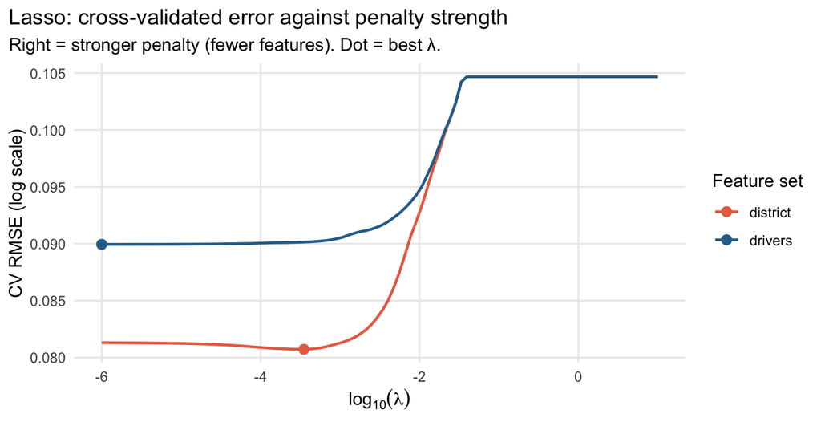

```r
lasso_curve <- imap_dfr(res_lasso, \(r, set) r$summary |> mutate(set = set))
p_lasso <- ggplot(lasso_curve, aes(log10(lambda), cv_rmse, colour = set)) +
  geom_line(linewidth = 0.8) +
  geom_point(data = lasso_curve |> group_by(set) |> slice_min(cv_rmse, n = 1), size = 2.5) +
  scale_colour_manual(values = c(drivers = "#2a6f97", district = "#e76f51")) +
  labs(title = "Lasso: cross-validated error against penalty strength",
       subtitle = "Right = stronger penalty (fewer features). Dot = best λ.",
       x = expression(log[10](lambda)), y = "CV RMSE (log scale)", colour = "Feature set")
save_fig(p_lasso, "fig16_lasso_cv_curve", height = 3.6)
```

**Observation.** The curve is flat at small λ (≈ OLS), then rises steeply once the penalty starts removing useful features. Results by feature set:

- **Drivers set** (~25 columns after dummies): the best λ is the smallest one tried, so the penalty does not help at all (CV RMSE 0.0899, the same as OLS). With 5,000 rows and few columns, OLS is not over-fitting.
- **District set** (~74 columns): a small penalty helps a little (0.0814 → 0.0807) by pulling the noisy effects of small districts towards the average. The gain is well inside one standard error (0.0024).

Ridge, elastic net and lasso end up almost identical, and close to plain OLS.

# 9 Generalised additive model (GAM)

**What it is.** prediction = intercept + f₁(x₁) + f₂(x₂) + …, where each fₖ is a smooth curve (a penalised regression spline) instead of a straight line or polynomial. It sits between polynomial regression (curves) and OLS (interpretable, additive).

**Tuned:** how wiggly each curve may be. `mgcv` chooses this itself by **REML**, which balances fit against smoothness inside a single fit, so there is no grid. `k = 6` caps each curve at 6 basis functions.

```r
fp_gam <- function(vars, y) function(tr, nw, p) {
  terms <- map_chr(vars, \(v) if (is_num(v)) sprintf("s(%s, k = 6)", v) else v)
  fit <- gam(as.formula(paste(y, "~", paste(terms, collapse = " + "))), data = tr, method = "REML")
  as.numeric(predict(fit, newdata = nw))
}
res_gam <- tune_model(fp_gam)
summarise_tuning(res_gam, "GAM (splines)") |> select(set, cv_rmse, cv_r2, seconds) |> kable(digits = 4)
```

| set | cv_rmse | cv_r2 | seconds |
| --- | --- | --- | --- |
| drivers | 0.0893 | 0.2480 | 33.7 |
| district | 0.0818 | 0.3732 | 81.4 |

**Observation.** The GAM does about as well as degree-2 polynomials (0.0893), which confirms that effects bend a little. Smooth curves, one feature at a time, do not close the gap to the tree ensembles below. That suggests the missing ingredient is *interactions* between features, not curvature.

# 10 Regression tree

**What it is.** The tree repeatedly splits the rows on one feature at a threshold and predicts the average of each final group. It captures thresholds and interactions and is easy to read, but a single tree is unstable: small changes in the data can change the splits.

**Tuned:**

- `cp`: the complexity parameter. A split is kept only if it improves fit by at least `cp` × the starting error. A small `cp` gives a big tree.
- `minbucket`: the smallest allowed leaf.

`xval = 0` turns off rpart’s own random CV because we use our time-ordered folds instead.

```r
fp_tree <- function(vars, y) function(tr, nw, p)
  predict(rpart(fml_of(y, vars), data = tr,
                control = rpart.control(cp = p$cp, minbucket = p$minbucket, xval = 0)), newdata = nw)

res_tree <- tune_model(fp_tree, grid = expand_grid(cp = c(0.0005, 0.001, 0.002, 0.005, 0.01, 0.02),
                                                   minbucket = c(10, 30, 60)))
summarise_tuning(res_tree, "Regression tree") |> select(set, best_settings, cv_rmse, cv_r2) |> kable(digits = 4)
```

| set | best_settings | cv_rmse | cv_r2 |
| --- | --- | --- | --- |
| drivers | cp = 0.002, minbucket = 30 | 0.0896 | 0.2481 |
| district | cp = 0.002, minbucket = 10 | 0.0844 | 0.3313 |

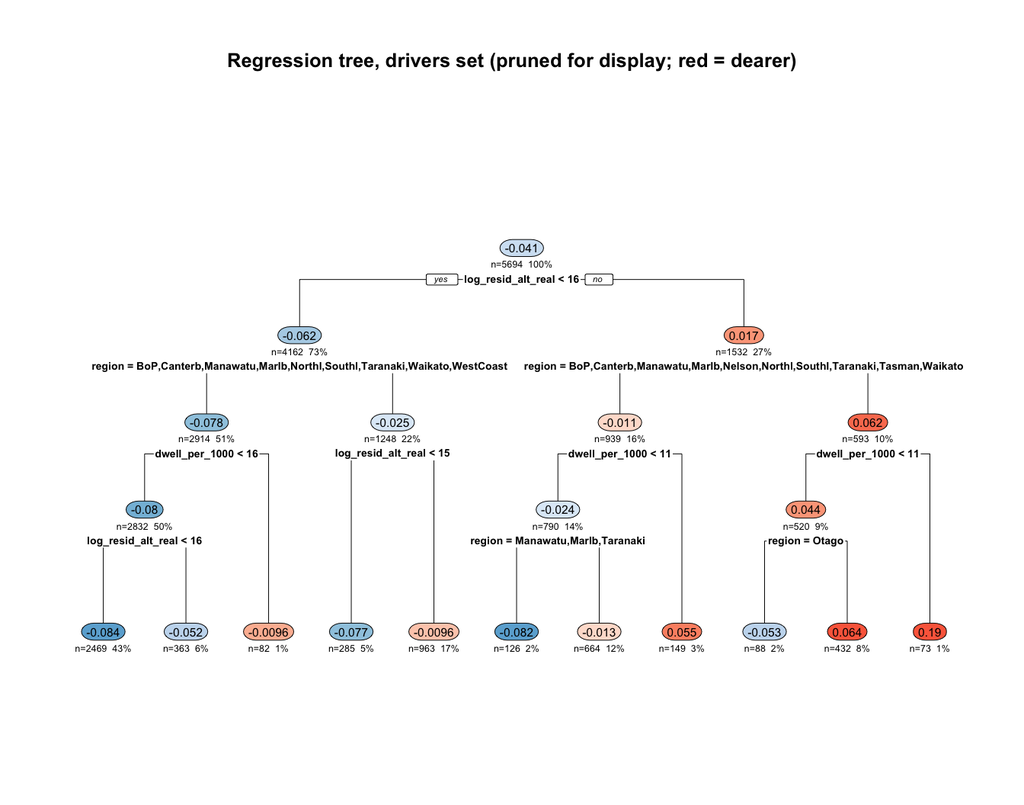

```r
best_tree <- res_tree$drivers$best
# short region names so the split labels fit on the page
short_region <- function(r) r |> str_remove(" Region") |>
  str_replace_all(c("Manawatu-Whanganui" = "Manawatu", "Bay of Plenty" = "BoP", "Hawke's Bay" = "HawkesBay",
                    "West Coast" = "WestCoast", "Marlborough" = "Marlb", "Canterbury" = "Canterb",
                    "Northland" = "Northl", "Southland" = "Southl", "Wellington" = "Wgtn"))
train_tree <- train |> mutate(region = fct_relabel(region, short_region))
tree_fit  <- rpart(fml_of(Y, fsets$drivers), data = train_tree,
                   control = rpart.control(cp = max(best_tree$cp, 0.005), minbucket = best_tree$minbucket, xval = 0))
draw_tree <- function() rpart.plot(tree_fit, type = 2, extra = 101, under = TRUE, roundint = FALSE,
                                   box.palette = "BuRd", tweak = 1.0, split.cex = 0.9,
                                   main = "Regression tree, drivers set (pruned for display; red = dearer)")
png(file.path(paths$fig_rq1, "fig17_regression_tree.png"), width = 11, height = 6, units = "in", res = 200)
draw_tree(); invisible(dev.off())
draw_tree()
```

**Observation.** The plotted tree is pruned a bit harder than the tuned one (`cp` ≥ 0.005) so it can be read. Each box shows the mean relative cost, the number of rows and their share. How to read it:

- The **first split is on residential alteration spending**: districts that spend more on renovations are dearer for new houses too.
- Then **region** separates the cheaper provincial regions.
- Then **dwellings per 1,000 residents** (fast-growing places) splits again.
- The dearest leaf (≈ +0.19, about 20% above the rest of NZ, 73 rows) is high-alteration, high-growth district-quarters in the regions *not* in the listed group (Auckland, Wellington, Otago, Gisborne, Hawke’s Bay, West Coast). In practice it is mostly Queenstown-Lakes.

The tuned tree (CV RMSE 0.0896) is about as accurate as OLS. One tree is too coarse to beat smoother models, but it shows the drivers *interacting*: the effect of growth depends on the region.

# 11 Random forest

**What it is.** Hundreds of deep trees, each grown on a bootstrap sample of the rows. At each split only a random subset of `mtry` features may be considered. Averaging many different trees removes most of a single tree’s instability.

**Tuned:**

- `mtry`: features tried at each split. Small values give more varied trees; `mtry` = all features is “bagging”.
- `min.node.size`: the smallest leaf. Larger values give smoother predictions.

The number of trees (500) is not really a tuning setting: more trees never hurt, they just take longer, and 500 is plenty here.

```r
fp_rf <- function(vars, y) function(tr, nw, p)
  predict(ranger(fml_of(y, vars), data = tr, num.trees = 500,
                 mtry = min(p$mtry, length(vars)), min.node.size = p$min.node.size,
                 num.threads = N_CORES, seed = 462), data = nw)$predictions

res_rf <- tune_model(fp_rf, grid = expand_grid(mtry = c(2, 4, 6, 8, 10), min.node.size = c(5, 20, 50)))
summarise_tuning(res_rf, "Random forest") |> select(set, best_settings, cv_rmse, cv_r2, seconds) |> kable(digits = 4)
```

| set | best_settings | cv_rmse | cv_r2 | seconds |
| --- | --- | --- | --- | --- |
| drivers | mtry = 6, min.node.size = 20 | 0.0855 | 0.3155 | 36.6 |
| district | mtry = 6, min.node.size = 5 | 0.0845 | 0.3323 | 42.4 |

```r
res_rf$drivers$summary |> select(mtry, min.node.size, cv_rmse) |>
  pivot_wider(names_from = min.node.size, values_from = cv_rmse, names_prefix = "min.node.size = ") |>
  arrange(mtry) |> kable(digits = 4, caption = "Drivers set: CV RMSE over the grid")
```

Drivers set: CV RMSE over the grid

| mtry | min.node.size = 20 | min.node.size = 5 | min.node.size = 50 |
| --- | --- | --- | --- |
| 2 | 0.0870 | 0.0866 | 0.0880 |
| 4 | 0.0857 | 0.0857 | 0.0863 |
| 6 | 0.0855 | 0.0856 | 0.0859 |
| 8 | 0.0856 | 0.0858 | 0.0857 |
| 10 | 0.0859 | 0.0861 | 0.0859 |

**Observation.** On the drivers set the random forest (0.0855, R² 0.32) clearly beats every linear model. The grid surface is fairly flat, so the forest isn’t sensitive to its exact settings, which is typical. Adding the district barely helps the forest (0.0845), and in that set it falls behind the linear models. Trees handle a 65-level category poorly: the district information gets spread across many small, noisy splits. A linear model gives each district its own intercept directly.

# 12 XGBoost (gradient-boosted trees)

**What it is.** Small trees are built one after another, each fitted to the errors left by the previous ones, and only a fraction `eta` (the learning rate) of each is added. A forest averages independent trees; boosting adds dependent ones.

**Tuned:**

- `max_depth`: how many splits deep each tree may go (its order of interactions).
- `min_child_weight`: the minimum size of a leaf.
- `nrounds`: how many trees. Too few under-fits; too many over-fits. As with λ for the lasso, one fit of 3,000 rounds lets us score every round count from 25 to 3,000 at no extra cost. The range goes up to 3,000 so that the chosen number of rounds is not at the edge of what we tried.

Fixed:

- `eta` = 0.03 (a slow, safe learning rate);
- `subsample` = `colsample_bytree` = 0.8 (each tree sees 80% of rows and features, which adds randomness like a forest).

```r
xgb_checkpoints <- seq(25, 3000, by = 25)

fp_xgb <- function(vars, y) function(tr, nw, p) {
  rhs <- rhs_of(vars)
  set.seed(462)
  booster <- xgb.train(
    params = list(objective = "reg:squarederror", eta = 0.03,
                  max_depth = p$max_depth, min_child_weight = p$min_child_weight,
                  subsample = 0.8, colsample_bytree = 0.8, nthread = N_CORES),
    data = xgb.DMatrix(make_x(tr, rhs), label = tr[[y]]),
    nrounds = max(xgb_checkpoints), verbose = 0)
  new_x <- xgb.DMatrix(make_x(nw, rhs))
  pred  <- sapply(xgb_checkpoints, \(k) predict(booster, new_x, iterationrange = c(1, k)))
  colnames(pred) <- xgb_checkpoints
  pred
}
res_xgb <- tune_model(fp_xgb, grid = expand_grid(max_depth = c(2, 4, 6, 8), min_child_weight = c(1, 10)),
                      inner = "nrounds")
summarise_tuning(res_xgb, "XGBoost") |> select(set, best_settings, cv_rmse, cv_r2, seconds) |> kable(digits = 4)
```

| set | best_settings | cv_rmse | cv_r2 | seconds |
| --- | --- | --- | --- | --- |
| drivers | nrounds = 150, max_depth = 8, min_child_weight = 1 | 0.0850 | 0.3251 | 64.1 |
| district | nrounds = 2020, max_depth = 2, min_child_weight = 1 | 0.0808 | 0.3918 | 73.8 |

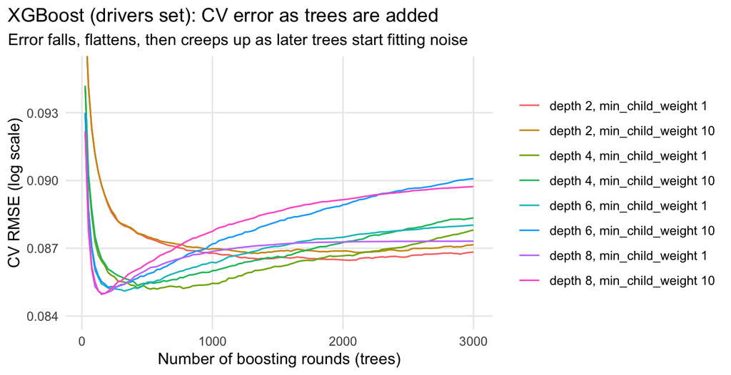

```r
xgb_curve <- res_xgb$drivers$summary |>
  mutate(setting = paste0("depth ", max_depth, ", min_child_weight ", min_child_weight))
p_xgb <- ggplot(xgb_curve, aes(nrounds, cv_rmse, colour = setting)) +
  geom_line() +
  coord_cartesian(ylim = c(min(xgb_curve$cv_rmse) - 0.001, min(xgb_curve$cv_rmse) + 0.01)) +
  labs(title = "XGBoost (drivers set): CV error as trees are added",
       subtitle = "Error falls, flattens, then creeps up as later trees start fitting noise",
       x = "Number of boosting rounds (trees)", y = "CV RMSE (log scale)", colour = NULL) +
  theme(legend.position = "right")
save_fig(p_xgb, "fig18_xgb_rounds", height = 3.6, width = 8)
```

**Observation.** The curves show the bias–variance trade-off:

- Deeper trees reach their best after a few hundred rounds and then get worse (over-fitting).
- Depth-2 trees learn slowly and keep improving for longer.
- The best settings sit in a broad, flat valley, so the exact choice matters little.

On the drivers set XGBoost (0.085) is level with the random forest. On the district set it prefers very shallow trees (depth 2, 2025 rounds). Shallow trees add up to something close to an additive model, which is what the linear models are telling us too.

# 13 Support vector machine (SVM) regression

**What it is.** With a radial kernel, the SVM predicts each row mainly from the training rows closest to it in feature space. Errors smaller than ε are ignored and larger ones are penalised with weight `cost`. Features are standardised first (`scale = TRUE`), because distances are meaningless when features have different units.

**Tuned:**

- `gamma` (γ): how local the influence of each training row is. A large γ gives a very wiggly fit.
- `cost`: how hard the model tries to fit every point. A large cost gives less smoothing.

ε is fixed at 0.05 (≈ 5% on the log scale).

```r
fp_svm <- function(vars, y) function(tr, nw, p) {
  rhs <- rhs_of(vars)
  fit <- svm(make_x(tr, rhs), tr[[y]], type = "eps-regression", kernel = "radial",
             cost = p$cost, gamma = p$gamma, epsilon = 0.05, scale = TRUE)
  as.numeric(predict(fit, make_x(nw, rhs)))
}
res_svm <- tune_model(fp_svm, grid = expand_grid(cost = c(0.3, 1, 3), gamma = c(0.002, 0.005, 0.01, 0.03, 0.1)))
summarise_tuning(res_svm, "SVM (radial)") |> select(set, best_settings, cv_rmse, cv_r2, seconds) |> kable(digits = 4)
```

| set | best_settings | cv_rmse | cv_r2 | seconds |
| --- | --- | --- | --- | --- |
| drivers | cost = 1, gamma = 0.03 | 0.0845 | 0.3310 | 99.0 |
| district | cost = 1, gamma = 0.005 | 0.0808 | 0.3886 | 285.6 |

**Observation.** The SVM is best or joint-best on the drivers set (0.0845) and close to the best on the district set (0.0808). It is the slowest to tune (286 s for the district set). Its predictions can’t be broken down by feature, so it is the hardest of the models to explain. The district set prefers a small γ, i.e. a smooth, nearly linear surface, again pointing to mostly additive effects once location is known.

# 14 Cross-validation comparison of all models

```r
model_order <- c("Overall mean", "District mean", "Linear regression", "Polynomial regression", "Ridge",
                 "Elastic net", "Lasso", "GAM (splines)", "Regression tree", "Random forest", "XGBoost",
                 "SVM (radial)")

# every model's tuning result, its factory, and its inner setting (if any)
spec <- list(
  "Overall mean"          = list(res = res_mean,     fp = fp_mean),
  "District mean"         = list(res = res_distmean, fp = fp_district_mean),
  "Linear regression"     = list(res = res_ols,      fp = fp_ols),
  "Polynomial regression" = list(res = res_poly,     fp = fp_poly),
  "Ridge"                 = list(res = res_ridge,    fp = fp_glmnet, inner = "lambda"),
  "Elastic net"           = list(res = res_enet,     fp = fp_glmnet, inner = "lambda"),
  "Lasso"                 = list(res = res_lasso,    fp = fp_glmnet, inner = "lambda"),
  "GAM (splines)"         = list(res = res_gam,      fp = fp_gam),
  "Regression tree"       = list(res = res_tree,     fp = fp_tree),
  "Random forest"         = list(res = res_rf,       fp = fp_rf),
  "XGBoost"               = list(res = res_xgb,      fp = fp_xgb, inner = "nrounds"),
  "SVM (radial)"          = list(res = res_svm,      fp = fp_svm)
)

cv_all <- imap_dfr(spec, \(s, m) summarise_tuning(s$res, m)) |>
  mutate(model = factor(model, levels = model_order),
         set = factor(set, levels = c("none", "drivers", "district"))) |>
  arrange(set, model)
cvv <- function(m, s, col = "cv_rmse") cv_all[[col]][cv_all$model == m & cv_all$set == s]   # for inline text
# later cached chunks (test, importance, real response) also depend on the tuning results
knitr::opts_chunk$set(cache.extra = list(file_md5, rlang::hash(list(train, test, folds, fsets, Y, cv_all))))
save_tab(cv_all, "t08_cv_results") |>
  select(set, model, best_settings, cv_rmse, cv_rmse_se, cv_mae, cv_r2, seconds) |>
  kable(digits = 4, caption = "Cross-validation results (training years only), best setting of each model")
```

Cross-validation results (training years only), best setting of each model

| set | model | best_settings | cv_rmse | cv_rmse_se | cv_mae | cv_r2 | seconds |
| --- | --- | --- | --- | --- | --- | --- | --- |
| none | Overall mean | (none) | 0.1047 | 0.0048 | 0.0801 | -0.0131 | 0.0 |
| none | District mean | (none) | 0.0841 | 0.0029 | 0.0644 | 0.3362 | 0.0 |
| drivers | Linear regression | (none) | 0.0899 | 0.0020 | 0.0692 | 0.2339 | 0.0 |
| drivers | Polynomial regression | degree = 2 | 0.0890 | 0.0017 | 0.0680 | 0.2521 | 0.2 |
| drivers | Ridge | lambda = 1e-06, alpha = 0 | 0.0899 | 0.0020 | 0.0692 | 0.2337 | 0.4 |
| drivers | Elastic net | lambda = 1e-06, alpha = 0.5 | 0.0899 | 0.0020 | 0.0692 | 0.2337 | 0.4 |
| drivers | Lasso | lambda = 1e-06, alpha = 1 | 0.0899 | 0.0020 | 0.0692 | 0.2336 | 0.4 |
| drivers | GAM (splines) | (none) | 0.0893 | 0.0016 | 0.0684 | 0.2480 | 33.7 |
| drivers | Regression tree | cp = 0.002, minbucket = 30 | 0.0896 | 0.0017 | 0.0692 | 0.2481 | 0.8 |
| drivers | Random forest | mtry = 6, min.node.size = 20 | 0.0855 | 0.0028 | 0.0653 | 0.3155 | 36.6 |
| drivers | XGBoost | nrounds = 150, max_depth = 8, min_child_weight = 1 | 0.0850 | 0.0023 | 0.0653 | 0.3251 | 64.1 |
| drivers | SVM (radial) | cost = 1, gamma = 0.03 | 0.0845 | 0.0027 | 0.0641 | 0.3310 | 99.0 |
| district | Linear regression | (none) | 0.0814 | 0.0024 | 0.0622 | 0.3782 | 0.2 |
| district | Polynomial regression | degree = 1 | 0.0814 | 0.0024 | 0.0622 | 0.3782 | 0.5 |
| district | Ridge | lambda = 0.00248, alpha = 0 | 0.0809 | 0.0024 | 0.0615 | 0.3856 | 0.6 |
| district | Elastic net | lambda = 0.000673, alpha = 0.5 | 0.0807 | 0.0024 | 0.0613 | 0.3881 | 0.4 |
| district | Lasso | lambda = 0.000351, alpha = 1 | 0.0807 | 0.0024 | 0.0613 | 0.3883 | 0.4 |
| district | GAM (splines) | (none) | 0.0818 | 0.0024 | 0.0629 | 0.3732 | 81.4 |
| district | Regression tree | cp = 0.002, minbucket = 10 | 0.0844 | 0.0033 | 0.0647 | 0.3313 | 0.7 |
| district | Random forest | mtry = 6, min.node.size = 5 | 0.0845 | 0.0026 | 0.0648 | 0.3323 | 42.4 |
| district | XGBoost | nrounds = 2020, max_depth = 2, min_child_weight = 1 | 0.0808 | 0.0029 | 0.0619 | 0.3918 | 73.8 |
| district | SVM (radial) | cost = 1, gamma = 0.005 | 0.0808 | 0.0025 | 0.0614 | 0.3886 | 285.6 |

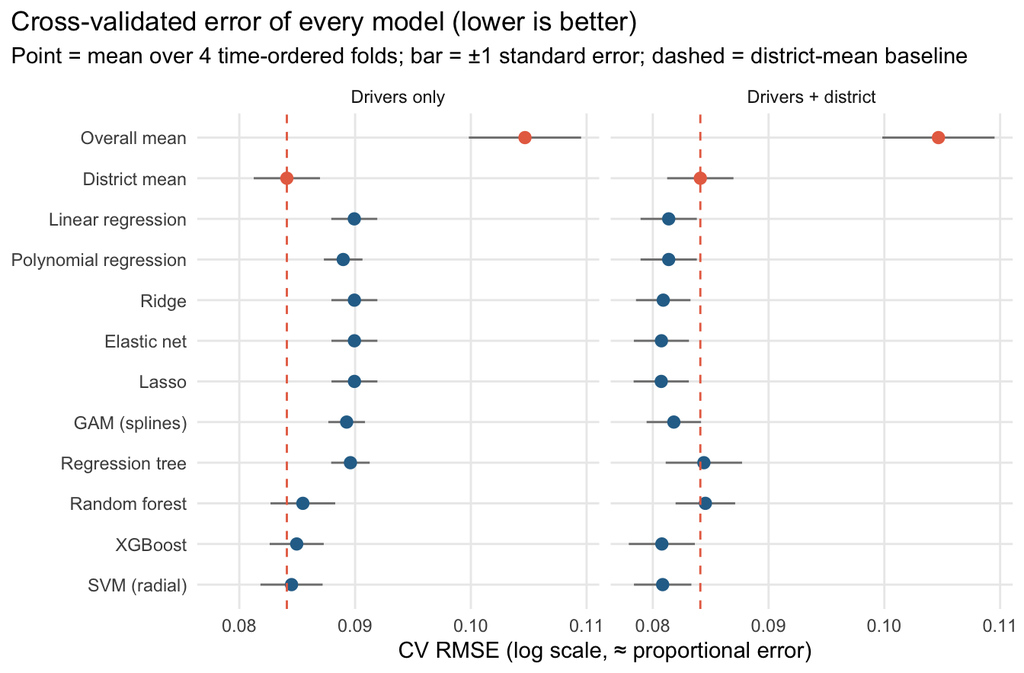

```r
cv_plot_df <- bind_rows(
  cv_all |> filter(set != "none"),
  cv_all |> filter(set == "none") |> mutate(set = "drivers"),
  cv_all |> filter(set == "none") |> mutate(set = "district")) |>
  mutate(set = factor(set, levels = c("drivers", "district"),
                      labels = c("Drivers only", "Drivers + district")))

p_cv <- ggplot(cv_plot_df, aes(cv_rmse, fct_rev(model))) +
  geom_linerange(aes(xmin = cv_rmse - cv_rmse_se, xmax = cv_rmse + cv_rmse_se), colour = "grey50") +
  geom_point(aes(colour = model %in% c("Overall mean", "District mean")), size = 2.4, show.legend = FALSE) +
  geom_vline(data = cv_plot_df |> filter(model == "District mean"), aes(xintercept = cv_rmse),
             linetype = 2, colour = "#e76f51") +
  scale_colour_manual(values = c(`TRUE` = "#e76f51", `FALSE` = "#2a6f97")) +
  facet_wrap(~set) +
  labs(title = "Cross-validated error of every model (lower is better)",
       subtitle = "Point = mean over 4 time-ordered folds; bar = ±1 standard error; dashed = district-mean baseline",
       x = "CV RMSE (log scale, ≈ proportional error)", y = NULL)
save_fig(p_cv, "fig19_cv_comparison", height = 4.6, width = 8)
```

```r
one_se <- cv_all |>
  filter(set != "none") |>
  group_by(set) |>
  mutate(best_rmse = min(cv_rmse),
         threshold = best_rmse + cv_rmse_se[which.min(cv_rmse)],
         within_1se = cv_rmse <= threshold) |>
  ungroup()

chosen <- one_se |> filter(within_1se) |> group_by(set) |> arrange(model) |> slice(1) |> ungroup()
one_se |> filter(within_1se) |> select(set, model, cv_rmse, threshold) |>
  kable(digits = 4, caption = "Models within one standard error of the best (listed simplest first)")
```

Models within one standard error of the best (listed simplest first)

| set | model | cv_rmse | threshold |
| --- | --- | --- | --- |
| drivers | Random forest | 0.0855 | 0.0872 |
| drivers | XGBoost | 0.0850 | 0.0872 |
| drivers | SVM (radial) | 0.0845 | 0.0872 |
| district | Linear regression | 0.0814 | 0.0831 |
| district | Polynomial regression | 0.0814 | 0.0831 |
| district | Ridge | 0.0809 | 0.0831 |
| district | Elastic net | 0.0807 | 0.0831 |
| district | Lasso | 0.0807 | 0.0831 |
| district | GAM (splines) | 0.0818 | 0.0831 |
| district | XGBoost | 0.0808 | 0.0831 |
| district | SVM (radial) | 0.0808 | 0.0831 |

```r
chosen |> select(set, model, best_settings, cv_rmse)  |> kable(digits = 4, caption = "Chosen by the 1-SE rule")
```

Chosen by the 1-SE rule

| set | model | best_settings | cv_rmse |
| --- | --- | --- | --- |
| drivers | Random forest | mtry = 6, min.node.size = 20 | 0.0855 |
| district | Linear regression | (none) | 0.0814 |

**Observation.** Three findings.

1. **Drivers only.** The flexible models form the top group:
   - random forest 0.0855;
   - XGBoost 0.085;
   - SVM 0.0845.

   They are ahead of the whole linear family (0.089–0.0899). They explain about a third of the variation in relative cost (CV R² ≈ 0.33), versus about a quarter for the linear models. The measured drivers matter in a non-linear, interacting way. **But no drivers-only model clearly beats the district-mean baseline** (0.0841). Our measured features recover about as much as simply knowing the district, and no more.
2. **Drivers + district.** Here the order flips: the **linear models are best** (lasso 0.0807, plain linear regression 0.0814, R² about 0.38). XGBoost and the SVM are level with them, while forests and single trees fall behind. Once each district has its own level, what is left is mostly additive and close to linear. These models beat the district-mean baseline by about 4% in RMSE. The drivers explain movements *around* each district’s usual level.
3. **The 1-SE rule** picks **Random forest** for the drivers set and **Linear regression** for the district set. These are the models we carry forward, but we still report every model on the test set.

# 15 Final evaluation on the test years (2020–2026)

Each model is refitted at its tuned settings on **all** 1996–2019 training rows, then scored once on the 1,600 test rows.

```r
test_pred <- imap_dfr(spec, function(s, m) {
  sets <- if (m %in% c("Overall mean", "District mean")) list(none = character(0)) else fsets
  preds <- refit_predict(s$fp, s$res, sets, Y, train, test, inner = s$inner)
  imap_dfr(preds, \(p, set) tibble(model = m, set = set, row = seq_along(p), pred = p))
})
```

```r
test_long <- test_pred |>
  left_join(test |> mutate(row = row_number()) |>
              select(row, ta, yq, year, obs = all_of(Y), loo_cost_m2, real_cost_m2), by = "row") |>
  mutate(pred_dollars = exp(pred) * loo_cost_m2)

test_res <- test_long |>
  group_by(model, set) |>
  summarise(reg_metrics(obs, pred), mape = mape(real_cost_m2, pred_dollars), .groups = "drop") |>
  left_join(cv_all |> select(model, set, cv_rmse), by = c("model", "set")) |>
  mutate(model = factor(model, levels = model_order),
         set = factor(set, levels = c("none", "drivers", "district"))) |>
  arrange(set, model) |>
  rename(test_rmse = rmse, test_mae = mae, test_r2 = r2, test_mape = mape)
tv <- function(m, s, col = "test_rmse") test_res[[col]][test_res$model == m & test_res$set == s]   # for inline text
save_tab(test_res, "t09_test_results") |>
  kable(digits = 4, caption = "Test-period scores (2020Q1–2026Q2). MAPE is on real $/m².")
```

Test-period scores (2020Q1–2026Q2). MAPE is on real $/m².

| model | set | test_rmse | test_mae | test_r2 | test_mape | cv_rmse |
| --- | --- | --- | --- | --- | --- | --- |
| Overall mean | none | 0.1362 | 0.1045 | -0.0490 | 0.1012 | 0.1047 |
| District mean | none | 0.1074 | 0.0821 | 0.3472 | 0.0797 | 0.0841 |
| Linear regression | drivers | 0.1162 | 0.0893 | 0.2358 | 0.0870 | 0.0899 |
| Polynomial regression | drivers | 0.1150 | 0.0883 | 0.2522 | 0.0858 | 0.0890 |
| Ridge | drivers | 0.1162 | 0.0893 | 0.2357 | 0.0870 | 0.0899 |
| Elastic net | drivers | 0.1162 | 0.0894 | 0.2357 | 0.0871 | 0.0899 |
| Lasso | drivers | 0.1163 | 0.0894 | 0.2357 | 0.0871 | 0.0899 |
| GAM (splines) | drivers | 0.1138 | 0.0878 | 0.2673 | 0.0856 | 0.0893 |
| Regression tree | drivers | 0.1183 | 0.0915 | 0.2084 | 0.0892 | 0.0896 |
| Random forest | drivers | 0.1134 | 0.0880 | 0.2729 | 0.0863 | 0.0855 |
| XGBoost | drivers | 0.1127 | 0.0866 | 0.2819 | 0.0848 | 0.0850 |
| SVM (radial) | drivers | 0.1115 | 0.0851 | 0.2965 | 0.0831 | 0.0845 |
| Linear regression | district | 0.1066 | 0.0811 | 0.3577 | 0.0792 | 0.0814 |
| Polynomial regression | district | 0.1066 | 0.0811 | 0.3577 | 0.0792 | 0.0814 |
| Ridge | district | 0.1073 | 0.0819 | 0.3489 | 0.0798 | 0.0809 |
| Elastic net | district | 0.1075 | 0.0821 | 0.3468 | 0.0800 | 0.0807 |
| Lasso | district | 0.1074 | 0.0820 | 0.3474 | 0.0799 | 0.0807 |
| GAM (splines) | district | 0.1061 | 0.0806 | 0.3631 | 0.0788 | 0.0818 |
| Regression tree | district | 0.1070 | 0.0814 | 0.3519 | 0.0793 | 0.0844 |
| Random forest | district | 0.1121 | 0.0867 | 0.2887 | 0.0851 | 0.0845 |
| XGBoost | district | 0.1080 | 0.0825 | 0.3400 | 0.0807 | 0.0808 |
| SVM (radial) | district | 0.1073 | 0.0814 | 0.3492 | 0.0795 | 0.0808 |

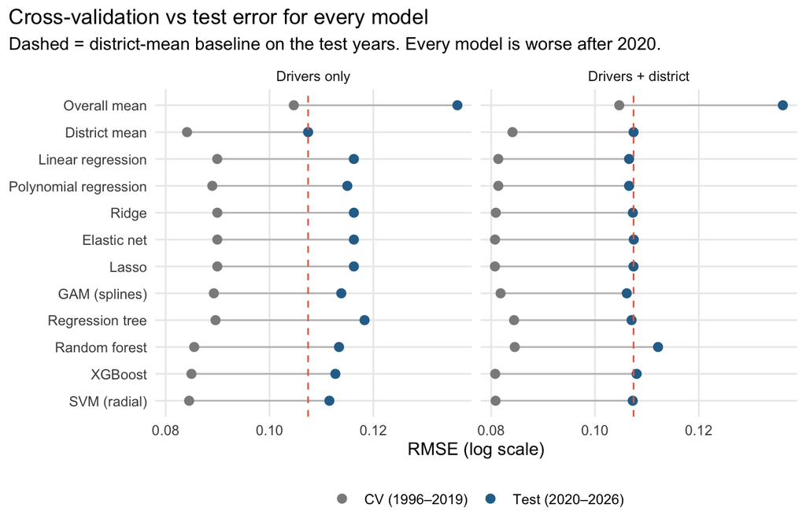

```r
cvtest_df <- bind_rows(
  test_res |> filter(set != "none"),
  test_res |> filter(set == "none") |> mutate(set = "drivers"),
  test_res |> filter(set == "none") |> mutate(set = "district")) |>
  mutate(set = factor(as.character(set), levels = c("drivers", "district"),
                      labels = c("Drivers only", "Drivers + district"))) |>
  pivot_longer(c(cv_rmse, test_rmse), names_to = "score", values_to = "rmse") |>
  mutate(score = recode(score, cv_rmse = "CV (1996–2019)", test_rmse = "Test (2020–2026)"))

p_cvtest <- ggplot(cvtest_df, aes(rmse, fct_rev(model))) +
  geom_line(aes(group = model), colour = "grey75") +
  geom_point(aes(colour = score), size = 2.3) +
  geom_vline(data = cvtest_df |> filter(model == "District mean", score == "Test (2020–2026)"),
             aes(xintercept = rmse), linetype = 2, colour = "#e76f51") +
  scale_colour_manual(values = c("CV (1996–2019)" = "grey55", "Test (2020–2026)" = "#2a6f97")) +
  facet_wrap(~set) +
  labs(title = "Cross-validation vs test error for every model",
       subtitle = "Dashed = district-mean baseline on the test years. Every model is worse after 2020.",
       x = "RMSE (log scale)", y = NULL, colour = NULL) +
  theme(legend.position = "bottom")
save_fig(p_cvtest, "fig20_cv_vs_test", height = 4.6, width = 8)
```

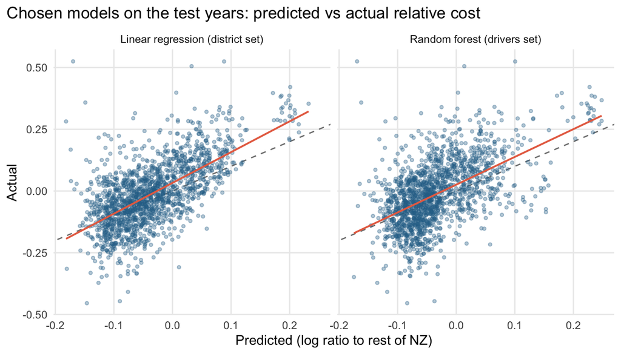

```r
chosen_pred <- test_long |> semi_join(chosen |> mutate(model = as.character(model), set = as.character(set)),
                                      by = c("model", "set")) |>
  mutate(panel = paste0(model, " (", set, " set)"))
p_pva <- ggplot(chosen_pred, aes(pred, obs)) +
  geom_abline(slope = 1, intercept = 0, colour = "grey50", linetype = 2) +
  geom_point(alpha = 0.35, size = 1, colour = "#2a6f97") +
  geom_smooth(method = "lm", se = FALSE, colour = "#e76f51", linewidth = 0.7) +
  facet_wrap(~panel) +
  labs(title = "Chosen models on the test years: predicted vs actual relative cost",
       x = "Predicted (log ratio to rest of NZ)", y = "Actual")
save_fig(p_pva, "fig21_test_pred_vs_actual", height = 4, width = 8)
```

**Observation.** Five points.

1. **Every model is worse on 2020–26 than in CV, including the overall mean** (0.136 vs 0.105). So part of this is not the models’ fault: districts were simply *more spread out* relative to each other in the COVID / boom / bust years. R² adjusts for this, and the R² values are close to the CV ones.
2. **The district set beats the drivers set again.** The best district-set model reaches test RMSE 0.1061 (R² ≈ 0.36). The best drivers-only model reaches 0.1115 (R² ≈ 0.3).
3. **The district-mean baseline is hard to beat out of sample.** It scores 0.1074 (MAPE 8.0%). The best models improve on it only marginally. In predictive terms, *where* a house is built tells you most of what our features can tell you.
4. **Chosen models:**
   - **Random forest, drivers:** test RMSE 0.1134, MAPE 8.6%;
   - **Linear regression, district:** test RMSE 0.1066, MAPE 7.9%.

   A typical district-quarter is predicted within about 8% of its actual $/m².
5. **The CV ranking mostly held:** flexible models led on drivers only, and linear models were competitive with district. The order *within* each top group shuffled, which is what you expect when differences are inside one standard error.

In the predicted-vs-actual plot, the fitted (orange) line is **steeper than 45° and sits slightly above it**. Steeper means the actual relative costs in 2020–26 were *more spread out* than the models predicted. The models are conservative: dear districts turned out even dearer and cheap ones even cheaper. Above means the average relative cost rose a little (Step 2: −0.04 → −0.01), which a model trained on 1996–2019 can’t know. Both match point 1.

# 16 What drives relative cost? (variable importance)

We use the **drivers** set here. In the district set, the district name absorbs most of the location effect and hides which measurable features matter. Three views from three different model types:

- **Lasso, standardised coefficients:** the size of each coefficient after features are put on the same scale (1 SD). The sign gives the direction.
- **Random forest, permutation importance:** how much the forest’s out-of-bag error rises when one feature’s values are shuffled (breaking its link to the response).
- **XGBoost, gain:** the share of total error reduction contributed by splits on each feature.

Dummy columns (regions) are added back together into one `region` score.

```r
vars <- fsets$drivers; rhs <- rhs_of(vars)
x_tr <- make_x(train, rhs)
base_var <- function(col) map_chr(col, \(cn) vars[which(startsWith(cn, vars))[1]])

# lasso at the CV-chosen lambda, coefficients x feature SD = standardised effect
lasso_fit <- glmnet(x_tr, train[[Y]], alpha = 1, lambda = lambda_grid)
b <- as.matrix(coef(lasso_fit, s = res_lasso$drivers$best$lambda))[-1, 1]
imp_lasso <- tibble(column = names(b), value = b * apply(x_tr, 2, sd)) |>
  mutate(feature = base_var(column)) |>
  group_by(feature) |> summarise(signed = value[which.max(abs(value))], importance = sum(abs(value)))

# random forest permutation importance at the tuned settings
bt <- res_rf$drivers$best
rf_fit <- ranger(fml_of(Y, vars), data = train, num.trees = 500, mtry = bt$mtry,
                 min.node.size = bt$min.node.size, importance = "permutation",
                 num.threads = N_CORES, seed = 462)
imp_rf <- tibble(feature = names(rf_fit$variable.importance), importance = rf_fit$variable.importance)

# xgboost gain at the tuned settings
bx <- res_xgb$drivers$best
set.seed(462)
xgb_fit <- xgb.train(params = list(objective = "reg:squarederror", eta = 0.03, max_depth = bx$max_depth,
                                   min_child_weight = bx$min_child_weight, subsample = 0.8,
                                   colsample_bytree = 0.8, nthread = N_CORES),
                     data = xgb.DMatrix(x_tr, label = train[[Y]]), nrounds = bx$nrounds, verbose = 0)
imp_xgb <- xgb.importance(model = xgb_fit) |> as_tibble() |>
  mutate(feature = base_var(Feature)) |> group_by(feature) |> summarise(importance = sum(Gain))

importance <- bind_rows(
  imp_lasso |> transmute(feature, method = "Lasso |std. coef|", importance, direction = sign(signed)),
  imp_rf    |> transmute(feature, method = "Random forest permutation", importance),
  imp_xgb   |> transmute(feature, method = "XGBoost gain", importance)) |>
  group_by(method) |> mutate(share = importance / sum(importance)) |> ungroup()
```

[figure not shown]

```r
imp_order <- importance |> group_by(feature) |> summarise(m = mean(share)) |> arrange(m) |> pull(feature)
lasso_sign <- importance |> filter(method == "Lasso |std. coef|") |> select(feature, direction)

p_imp <- importance |>
  left_join(lasso_sign, by = "feature", suffix = c("", "_lasso")) |>
  mutate(feature = factor(feature, levels = imp_order),
         dir = case_when(feature %in% c("region") ~ "category",
                         direction_lasso > 0 ~ "dearer when higher",
                         direction_lasso < 0 ~ "cheaper when higher",
                         TRUE ~ "dropped by lasso")) |>
  ggplot(aes(share, feature, fill = dir)) +
  geom_col() +
  facet_wrap(~method) +
  scale_fill_manual(values = c(`dearer when higher` = "#e76f51", `cheaper when higher` = "#2a6f97",
                               category = "grey60", `dropped by lasso` = "grey85")) +
  scale_x_continuous(labels = scales::percent) +
  labs(title = "What drives a district's relative cost per m²? (drivers set, training years)",
       subtitle = "Share of each model's total importance; colour = direction in the lasso",
       x = "Share of importance", y = NULL, fill = NULL) +
  theme(legend.position = "bottom")
save_fig(p_imp, "fig22_variable_importance", height = 4.8, width = 9)
```

```r
importance |> select(feature, method, share) |>
  pivot_wider(names_from = method, values_from = share) |>
  arrange(desc(`Random forest permutation`)) |>
  save_tab("t10_variable_importance") |>
  kable(digits = 3, caption = "Share of importance by method")
```

Share of importance by method

| feature | Lasso \|std. coef\| | Random forest permutation | XGBoost gain |
| --- | --- | --- | --- |
| log_resid_alt_real | 0.206 | 0.282 | 0.245 |
| region | 0.500 | 0.204 | 0.195 |
| dwell_per_1000 | 0.132 | 0.183 | 0.146 |
| log_houses_n | 0.099 | 0.141 | 0.092 |
| log_nonres_real | 0.003 | 0.060 | 0.071 |
| rel_house_m2 | 0.029 | 0.045 | 0.100 |
| is_city | 0.012 | 0.030 | 0.009 |
| multiunit_share | 0.003 | 0.023 | 0.043 |
| apt_share | 0.006 | 0.014 | 0.012 |
| houses_yoy | 0.007 | 0.008 | 0.073 |
| retire_share | 0.003 | 0.008 | 0.014 |

Next come **relative house size** (bigger houses are cheaper per m², because fixed costs such as kitchens and bathrooms are spread over more floor area), then non-residential activity and growth. The dwelling-mix shares (apartments, townhouses, retirement) matter little.

Remember these are *associations* in observational data. For example, more alteration spending in a district does not *cause* dearer new houses; both reflect a wealthier, busier building market. Step 4 will look at *how* each top driver changes predictions (partial dependence) and at which districts the model gets wrong.

# 17 Secondary response: log real $/m² and the extrapolation problem

The pitch’s original target was real $/m² itself. Here we add the national time trend `t_index` and use `avg_house_m2` (absolute size), and fit a subset of the models on the same folds.

```r
Y2 <- "log_real_cost_m2"
num_real <- c("avg_house_m2", setdiff(num_main, "rel_house_m2"), "t_index")
fsets_real <- list(drivers = c(num_real, "region", "is_city"), district = c(num_real, "ta"))

real_spec <- list(
  "District mean"     = list(fp = fp_district_mean, sets = list(none = character(0))),
  "Linear regression" = list(fp = fp_ols),
  "Lasso"             = list(fp = fp_glmnet, grid = tibble(alpha = 1), inner = "lambda"),
  "Regression tree"   = list(fp = fp_tree, grid = expand_grid(cp = c(0.001, 0.002, 0.005, 0.01), minbucket = c(10, 30))),
  "Random forest"     = list(fp = fp_rf, grid = expand_grid(mtry = c(4, 8), min.node.size = c(5, 20))),
  "XGBoost"           = list(fp = fp_xgb, grid = expand_grid(max_depth = c(4, 6), min_child_weight = c(1, 10)),
                             inner = "nrounds")
)
real_res <- imap(real_spec, function(s, m) {
  sets <- s$sets %||% fsets_real
  r    <- tune_model(s$fp, grid = s$grid, inner = s$inner, sets = sets, y = Y2)
  p    <- refit_predict(s$fp, r, sets, Y2, train, test, inner = s$inner)
  list(res = r, pred = p)
})
```

```r
real_test <- imap_dfr(real_res, function(x, m) imap_dfr(x$pred, \(p, set)
  tibble(model = m, set = set, row = seq_along(p), pred = p))) |>
  left_join(test |> mutate(row = row_number()) |> select(row, yq, year, obs = log_real_cost_m2, real_cost_m2),
            by = "row")

real_table <- real_test |>
  group_by(model, set) |>
  summarise(reg_metrics(obs, pred), mape = mape(real_cost_m2, exp(pred)),
            mean_bias = mean(pred - obs), .groups = "drop") |>
  left_join(imap_dfr(real_res, \(x, m) summarise_tuning(x$res, m)) |> select(model, set, cv_rmse),
            by = c("model", "set")) |>
  rename(test_rmse = rmse, test_mae = mae, test_r2 = r2, test_mape = mape) |>
  arrange(set, test_rmse)
save_tab(real_table, "t11_real_response_results") |>
  kable(digits = 4, caption = "Log real $/m² (with time trend): CV and test scores. mean_bias < 0 = under-predicts.")
```

Log real $/m² (with time trend): CV and test scores. mean_bias < 0 = under-predicts.

| model | set | test_rmse | test_mae | test_r2 | test_mape | mean_bias | cv_rmse |
| --- | --- | --- | --- | --- | --- | --- | --- |
| XGBoost | district | 0.1019 | 0.0776 | 0.4052 | 0.0770 | -0.0077 | 0.0791 |
| Linear regression | district | 0.1070 | 0.0822 | 0.3444 | 0.0847 | 0.0306 | 0.0890 |
| Lasso | district | 0.1077 | 0.0834 | 0.3353 | 0.0859 | 0.0286 | 0.0880 |
| Random forest | district | 0.1108 | 0.0848 | 0.2969 | 0.0831 | -0.0199 | 0.0825 |
| Regression tree | district | 0.1165 | 0.0895 | 0.2228 | 0.0859 | -0.0436 | 0.0833 |
| XGBoost | drivers | 0.1079 | 0.0822 | 0.3339 | 0.0811 | -0.0132 | 0.0831 |
| Random forest | drivers | 0.1105 | 0.0840 | 0.3004 | 0.0817 | -0.0254 | 0.0847 |
| Linear regression | drivers | 0.1167 | 0.0914 | 0.2206 | 0.0946 | 0.0342 | 0.0965 |
| Lasso | drivers | 0.1197 | 0.0940 | 0.1795 | 0.0957 | 0.0187 | 0.0958 |
| Regression tree | drivers | 0.1212 | 0.0941 | 0.1582 | 0.0907 | -0.0382 | 0.0918 |
| District mean | none | 0.1924 | 0.1665 | -1.1194 | 0.1498 | -0.1612 | 0.1411 |

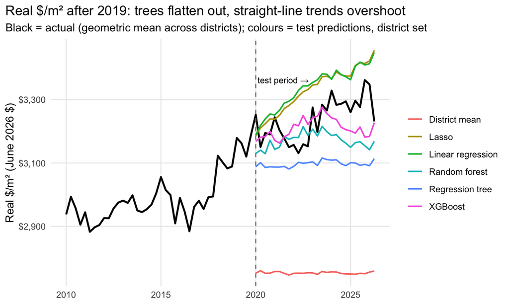

```r
real_nat <- real_test |>
  filter(set %in% c("district", "none")) |>
  group_by(model, yq, year) |>
  summarise(pred = exp(mean(pred)), .groups = "drop") |>
  mutate(t = as.numeric(substr(yq, 1, 4)) + (as.numeric(substr(yq, 6, 6)) - 1) / 4)
actual_nat <- dat |> filter(year >= 2010) |> group_by(yq) |>
  summarise(actual = exp(mean(log_real_cost_m2)), .groups = "drop") |>
  mutate(t = as.numeric(substr(yq, 1, 4)) + (as.numeric(substr(yq, 6, 6)) - 1) / 4)

p_real <- ggplot() +
  geom_line(data = actual_nat, aes(t, actual), colour = "black", linewidth = 0.9) +
  geom_line(data = real_nat, aes(t, pred, colour = model), linewidth = 0.7) +
  geom_vline(xintercept = 2020, linetype = 2, colour = "grey50") +
  annotate("text", x = 2020.1, y = max(actual_nat$actual), label = "test period →", hjust = 0, size = 3) +
  scale_y_continuous(labels = scales::dollar_format(accuracy = 1)) +
  labs(title = "Real $/m² after 2019: trees flatten out, straight-line trends overshoot",
       subtitle = "Black = actual (geometric mean across districts); colours = test predictions, district set",
       x = NULL, y = "Real $/m² (June 2026 $)", colour = NULL) +
  theme(legend.position = "right")
save_fig(p_real, "fig23_real_cost_extrapolation", height = 4.2, width = 8)
```

**Observation.** Each model family fails in its own characteristic way once it has to predict a *level* it never saw:

- **District mean:** ignores time entirely and under-predicts by about 16%.
- **Regression tree and random forest:** predictions flatten at roughly the last level in the training data and stay there (mean bias -0.044 and -0.02). A tree can only output averages of training rows, so `t_index` beyond 2019 is treated like 2019.
- **Linear and lasso:** they carry the 1996–2019 trend forward as a straight line and **overshoot** (mean bias +0.031), because real costs after 2019 rose more slowly than the 1996–2019 trend.
- **XGBoost** happens to land closest. It leans on activity features (alterations, growth) that *did* move in the test years, rather than on the clock. That is a lucky proxy, not a reliable mechanism.

This is why the **relative** response is the main one for RQ1. It removes the national level, so no model has to guess the future price level, and it asks a question that the pre-2020 data can answer.

# 18 Summary and next step

```r
saveRDS(list(cv = cv_all, test = test_res, chosen = chosen, importance = importance,
             real = real_table, test_predictions = test_long,
             best_settings = map(spec, \(s) map(s$res, "best"))),
        file.path(paths$models_rq1, "rq1_step3_results.rds"))
list.files(paths$models_rq1)
```

```
## [1] "rq1_final_models.rds"  "rq1_step3_results.rds"
```

| # | Finding | Consequence |
| --- | --- | --- |
| 1 | With drivers only, the flexible models (forest, XGBoost, SVM) beat the linear family: CV R² ≈ 0.32 vs 0.23–0.25. | The drivers act non-linearly and in combination. |
| 2 | No drivers-only model clearly beats “each district’s own average” (CV or test). | Our measured features capture roughly what location captures, not more. Part of the location effect remains unexplained (land, terrain, local costs). |
| 3 | With the district added, linear models are best (CV R² ≈ 0.38–0.39), and they beat the district mean. The penalty adds little, so the 1-SE rule keeps plain linear regression. | The drivers explain movements around each district’s usual level, and mostly additively. |
| 4 | Main drivers: alteration spending (+), region, dwellings per 1,000 residents (+), number of new houses (−), house size (−). | This is the answer to “what drives” for the report. Step 4 will show the shapes. |
| 5 | Every model is worse in 2020–26, the baseline included. | The test years were unusually dispersed (COVID, boom, bust). The ranking mostly held. |
| 6 | On real $/m², trees flatten and linear trends overshoot. | Confirms the relative response as the main RQ1 target. |

**Step 4 (next):**

- interpret the chosen models (partial-dependence plots for the top drivers);
- look at test errors by district and year (where is the model wrong?);
- optionally refine the tuning grid around the winner;
- write the RQ1 answer for the report.

# 19 Appendix: helper functions

This notebook uses helper functions from `R/utils_data.R` and `R/utils_models.R`, printed here so the document is complete on its own.

```r
# =============================================================================
# R/utils_data.R
# Shared helpers for reading and reshaping Stats NZ data.
# Source this from any Rmd after the project root has been set:
#   source(file.path(proj_root, "R", "utils_data.R"))
# =============================================================================

suppressPackageStartupMessages({
  library(data.table)
  library(tidyverse)
})

# ---- Paths (all relative to the project root) -------------------------------
paths <- list(
  raw_extracted = "data/raw/extracted",
  raw_cgpi      = "data/raw/external/cgpi",
  reference     = "data/reference",
  processed     = "data/processed",
  fig_rq1       = "outputs/figures/rq1",
  tab_rq1       = "outputs/tables/rq1",
  fig_rq2       = "outputs/figures/rq2",
  tab_rq2       = "outputs/tables/rq2"
)

# ---- Reading Stats NZ "Infoshare" long-format CSVs --------------------------
# Every Infoshare file has one row per (series x period). We read only the
# columns that carry information and give them short working names.
#
# Notes
# * `Period` MUST be read as text: as a number, "2025.10" becomes 2025.1,
#   which is indistinguishable from January.
# * integer64 is turned off so that large dollar values come back as doubles
#   (integer64 silently overflows on division).
read_infoshare <- function(file,
                           dir = paths$raw_extracted,
                           keep_status = FALSE) {
  cols <- c("Series_reference", "Period", "Data_value",
            "Series_title_1", "Series_title_2",
            "Series_title_3", "Series_title_4", "Series_title_5")
  if (keep_status) cols <- c(cols, "Status")

  dt <- fread(file.path(dir, file),
              select      = cols,
              colClasses  = list(character = "Period"),
              integer64   = "double",
              na.strings  = c("", "NA"),
              showProgress = FALSE)

  as_tibble(dt) |>
    rename(series  = Series_reference,
           period  = Period,
           value   = Data_value,
           area    = Series_title_1,
           btype   = Series_title_2,
           work    = Series_title_3,
           measure = Series_title_4,
           adjust  = Series_title_5)   # Actual / Seasonally adjusted / Trend (regional files only)
}

# ---- Period helpers ----------------------------------------------------------
# "YYYY.MM" -> integer year / month / calendar quarter
period_year    <- function(p) as.integer(substr(p, 1, 4))
period_month   <- function(p) as.integer(substr(p, 6, 7))
month_quarter  <- function(m) (m - 1L) %/% 3L + 1L

# Label like "2019Q3"
yq_label <- function(year, quarter) paste0(year, "Q", quarter)

# Sequential quarter index (1990Q1 = 1) - handy as a numeric time trend
yq_index <- function(year, quarter) (year - 1990L) * 4L + quarter

# ---- GST ---------------------------------------------------------------------
# Consent values are GST-inclusive. GST was 12.5% from 1 Jul 1989 to
# 30 Sep 2010 and 15% from 1 Oct 2010. Every month in our data is >= 1990,
# so only these two rates apply. Quarter boundaries line up with the change
# (2010Q4 starts on 1 Oct 2010), so a quarter-level rule is exact.
gst_rate <- function(year, quarter) {
  if_else(yq_index(year, quarter) >= yq_index(2010L, 4L), 0.15, 0.125)
}

# ---- Small display helpers ---------------------------------------------------
fmt_int <- function(x) format(round(x), big.mark = ",", scientific = FALSE)
fmt_dol <- function(x) paste0("$", fmt_int(x))
fmt_pct <- function(x, d = 1) paste0(format(round(100 * x, d), nsmall = d), "%")

# ---- Figures -----------------------------------------------------------------
theme_set(theme_minimal(base_size = 11) +
            theme(plot.title.position = "plot",
                  panel.grid.minor = element_blank()))

# Save a ggplot as PNG (for the report) and return it (so it also shows in the Rmd)
save_fig <- function(p, name, dir = paths$fig_rq1, width = 7, height = 4.2) {
  dir.create(dir, recursive = TRUE, showWarnings = FALSE)
  ggsave(file.path(dir, paste0(name, ".png")), p,
         width = width, height = height, dpi = 200, bg = "white")
  p
}

# Save a table as CSV (for the report) and return it
save_tab <- function(df, name, dir = paths$tab_rq1) {
  dir.create(dir, recursive = TRUE, showWarnings = FALSE)
  write_csv(df, file.path(dir, paste0(name, ".csv")))
  df
}
```

```r
# =============================================================================
# R/utils_models.R
# Shared helpers for fitting, tuning and comparing models (Step 3 onwards).
# Source AFTER utils_data.R:
#   source(file.path(proj_root, "R", "utils_data.R"))
#   source(file.path(proj_root, "R", "utils_models.R"))
#
# The idea: every model is written as ONE function
#     fit_predict(train_df, new_df, params)  ->  predictions for new_df
# and the same tuning / scoring code is used for all of them. That way every
# model is judged on exactly the same folds with exactly the same metrics.
# =============================================================================

paths$models_rq1 <- "outputs/models/rq1"

# ---- Metrics -----------------------------------------------------------------
# obs, pred: numeric vectors on the LOG scale.
#   rmse  root mean squared error   (penalises big misses more)
#   mae   mean absolute error       (typical miss)
#   r2    1 - SSE / SST             (share of variance explained, on these rows)
# On the log scale an error of 0.10 is roughly a 10% miss in $/m².
reg_metrics <- function(obs, pred) {
  e <- pred - obs
  tibble(rmse = sqrt(mean(e^2)),
         mae  = mean(abs(e)),
         r2   = 1 - sum(e^2) / sum((obs - mean(obs))^2))
}

# MAPE on the dollar scale: mean |predicted - actual| / actual
mape <- function(obs_dollars, pred_dollars) mean(abs(pred_dollars - obs_dollars) / obs_dollars)

# ---- Time-ordered cross-validation folds ------------------------------------
# "Forward-chaining" (rolling-origin) CV: each fold trains on all years BEFORE a
# validation block and validates on that block. This mimics the real task
# (learn from the past, predict the future) and never lets a model peek ahead.
#   years        : the year of every training row
#   valid_blocks : list of year vectors, one per fold
# Returns a named list of folds, each with $train and $valid row numbers.
make_time_folds <- function(years,
                            valid_blocks = list(2012:2013, 2014:2015, 2016:2017, 2018:2019)) {
  folds <- lapply(valid_blocks, function(b)
    list(train = which(years < min(b)), valid = which(years %in% b)))
  names(folds) <- vapply(valid_blocks, function(b) paste0("valid ", min(b), "-", max(b)), "")
  folds
}

# ---- Generic tuner -----------------------------------------------------------
# fit_predict(train_df, new_df, params) must return either
#   * a numeric vector (one prediction per row of new_df), or
#   * a matrix with one column per value of an "inner" setting that one fit can
#     produce for free (lambda for glmnet, number of rounds for xgboost). The
#     column names hold that setting's value and `inner` names it.
#     The values are rounded to 6 significant figures before grouping: going
#     through column names (text) can change the last digits, and then the
#     same lambda would not match across folds.
# grid: data frame, one row per combination of settings to try.
# Returns list(folds = per-fold scores, summary = mean score per setting,
#              best = the setting with the lowest mean RMSE).
cv_tune <- function(fit_predict, grid, data, folds, response, inner = NULL) {
  grid <- as_tibble(grid)
  if (nrow(grid) == 0) grid <- tibble(.dummy = 1)

  per_fold <- map_dfr(seq_len(nrow(grid)), function(g) {
    params <- as.list(grid[g, , drop = FALSE])
    map_dfr(names(folds), function(fn) {
      f    <- folds[[fn]]
      pred <- fit_predict(data[f$train, ], data[f$valid, ], params)
      pred <- as.matrix(pred)
      if (is.null(colnames(pred))) colnames(pred) <- "0"
      obs  <- data[[response]][f$valid]
      map_dfr(colnames(pred), function(cn)
        reg_metrics(obs, pred[, cn]) |>
          mutate(config = g, inner_value = signif(as.numeric(cn), 6), fold = fn, n_valid = length(obs)))
    })
  })

  summary <- per_fold |>
    group_by(config, inner_value) |>
    summarise(cv_rmse = mean(rmse), cv_rmse_sd = sd(rmse),
              cv_mae = mean(mae), cv_r2 = mean(r2), .groups = "drop") |>
    left_join(grid |> mutate(config = row_number()), by = "config") |>
    select(-any_of(".dummy")) |>
    arrange(cv_rmse)
  if (!is.null(inner)) summary <- rename(summary, !!inner := inner_value)
  else summary <- select(summary, -inner_value)

  list(folds = per_fold, summary = summary, best = summary[1, ])
}

# ---- Design matrix with a fixed set of columns ------------------------------
# glmnet, xgboost and svm need a numeric matrix, not a data frame with factors.
# model.matrix() turns each factor into 0/1 "dummy" columns. Because our factors
# carry ALL their levels, train and test matrices always get the same columns.
make_x <- function(df, rhs) {
  model.matrix(as.formula(paste("~", rhs)), data = df)[, -1, drop = FALSE]  # drop intercept
}

# ---- Timing helper -----------------------------------------------------------
# Runs an expression and returns its value with the elapsed seconds attached.
timed <- function(expr) {
  t0  <- Sys.time()
  out <- force(expr)
  attr(out, "seconds") <- as.numeric(difftime(Sys.time(), t0, units = "secs"))
  out
}

# ---- Summarising tuning results ---------------------------------------------
# res_by_set: a named list (one element per feature set) of cv_tune() results.
# Returns one row per feature set: the best setting found and its CV scores.
settings_text <- function(best) {
  b <- best |> select(-any_of(c("config", "cv_rmse", "cv_rmse_sd", "cv_mae", "cv_r2")))
  if (ncol(b) == 0) return("(none)")
  paste(names(b), signif(unlist(b), 3), sep = " = ", collapse = ", ")
}

summarise_tuning <- function(res_by_set, model) {
  imap_dfr(res_by_set, function(r, set)
    tibble(model = model, set = set,
           cv_rmse = r$best$cv_rmse, cv_rmse_se = r$best$cv_rmse_sd / sqrt(n_distinct(r$folds$fold)),
           cv_mae = r$best$cv_mae, cv_r2 = r$best$cv_r2,
           n_settings_tried = nrow(r$summary),
           best_settings = settings_text(r$best),
           seconds = round(attr(r, "seconds"), 1)))
}

# ---- Refit the best setting on ALL training rows and predict new rows -------
# factory(vars, y) returns a fit_predict function (see cv_tune). For models with
# an inner setting, the prediction column closest to the chosen value is kept.
refit_predict <- function(factory, res_by_set, sets, y, train_df, new_df, inner = NULL) {
  imap(sets, function(vars, set) {
    best <- res_by_set[[set]]$best
    pred <- as.matrix(factory(vars, y)(train_df, new_df, as.list(best)))
    if (!is.null(inner))
      pred <- pred[, which.min(abs(as.numeric(colnames(pred)) - best[[inner]])), drop = FALSE]
    as.numeric(pred)
  })
}
```